# Turbofan Engine Remaining Useful Life

## Casptone Project

[figure not shown]

Internal View of a Jet/Turbofan Engine

## Overview

The main goal of this document is to provide an approach to the implementaion of a model that can be use to predict the the Remaining Useful Life of a series of Jet Engines the dataset used for this project has been obtained from a NASA public available source [^1]

The dataset consists in 3 diferent files: - RUL_FD001.txt - test_FD001.txt - train_FD001.txt

In the test_FD001 file the data for operational settings and sensor is provided however the last cycle number doesn’t represent the failure cycle, the real cycle number for each engine on the test set is provided by the file RUL_FD001. All engines are the same model.

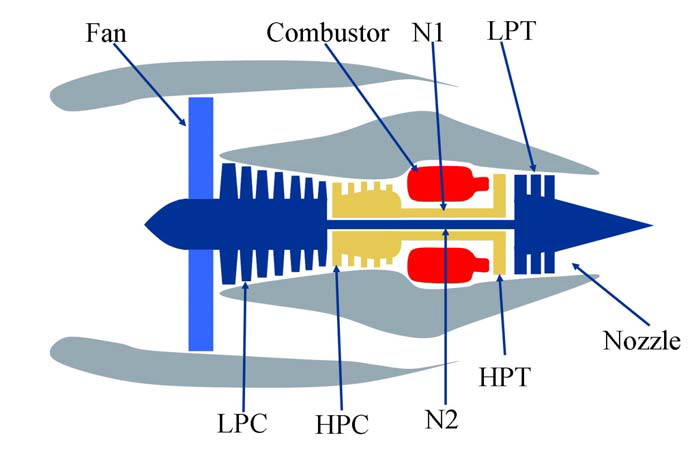

Breakdown of Internal components of a Jet/Turbofan Engine

#### Research Question

In the asset maintenance world predictive maintenance is gaining more importance because Implementing a predictive maintenance programs can result in:

- Savings of 30-40 percent
- 10-fold return on investment (ROI)
- Maintenance cost reduction of 25-30 percent
- Breakdown elimination of up to 75 percent
- Reduction in downtime from 35-45 percent
- Increase in production of 20-25 percent. A manufacturer has the ability to shift from reactive maintenance to dispatch a technician with a preventive maintenance work order on an ‘as needed’ basis and ensure that repair parts are in inventory prior to downtime [^2]

Given the data provided in the datasets, we’d like to create a model to predict the RUL (Remaining Useful Life). In consequence we will try to answer the following question:

> **Is it possible to predict the RUL of same model Jet Engines based on Operational Setting and sensor collected data?**

Loading Datasets and Formating columns

```r
# Load Dataset for Study
test <- read_delim("test_FD001.txt", delim = " ", col_names = FALSE)
train <- read_delim("train_FD001.txt", delim = " ", col_names = FALSE)
CTF <- read_csv("RUL_FD001.txt", col_names = FALSE)
# Set header Names for Train set
names(train) <- c('UnitNum','TimeCycles','OperSet1','OperSet2','OperSet3','SensorRead01','SensorRead02','SensorRead03','SensorRead04','SensorRead05'
                  ,'SensorRead06','SensorRead07','SensorRead08','SensorRead09','SensorRead10','SensorRead11','SensorRead12','SensorRead13','SensorRead14'
                  ,'SensorRead15','SensorRead16','SensorRead17','SensorRead18','SensorRead19','SensorRead20','SensorRead21','CyclesToFail')

# Set header Names for Test set
names(test) <- c('UnitNum','TimeCycles','OperSet1','OperSet2','OperSet3','SensorRead01','SensorRead02','SensorRead03','SensorRead04','SensorRead05'
                 ,'SensorRead06','SensorRead07','SensorRead08','SensorRead09','SensorRead10','SensorRead11','SensorRead12','SensorRead13','SensorRead14'
                 ,'SensorRead15','SensorRead16','SensorRead17','SensorRead18','SensorRead19','SensorRead20','SensorRead21','CyclesToFail')

# Set header Names for RUL number applicable to Test set
names(CTF) <- c('CyclesToFail')

summary(train)
```

```
##     UnitNum         TimeCycles       OperSet1            OperSet2
##  Min.   :  1.00   Min.   :  1.0   Min.   :-8.70e-03   Min.   :-6.000e-04
##  1st Qu.: 26.00   1st Qu.: 52.0   1st Qu.:-1.50e-03   1st Qu.:-2.000e-04
##  Median : 52.00   Median :104.0   Median : 0.00e+00   Median : 0.000e+00
##  Mean   : 51.51   Mean   :108.8   Mean   :-8.87e-06   Mean   : 2.351e-06
##  3rd Qu.: 77.00   3rd Qu.:156.0   3rd Qu.: 1.50e-03   3rd Qu.: 3.000e-04
##  Max.   :100.00   Max.   :362.0   Max.   : 8.70e-03   Max.   : 6.000e-04
##     OperSet3    SensorRead01    SensorRead02    SensorRead03   SensorRead04
##  Min.   :100   Min.   :518.7   Min.   :641.2   Min.   :1571   Min.   :1382
##  1st Qu.:100   1st Qu.:518.7   1st Qu.:642.3   1st Qu.:1586   1st Qu.:1402
##  Median :100   Median :518.7   Median :642.6   Median :1590   Median :1408
##  Mean   :100   Mean   :518.7   Mean   :642.7   Mean   :1591   Mean   :1409
##  3rd Qu.:100   3rd Qu.:518.7   3rd Qu.:643.0   3rd Qu.:1594   3rd Qu.:1415
##  Max.   :100   Max.   :518.7   Max.   :644.5   Max.   :1617   Max.   :1441
##   SensorRead05    SensorRead06    SensorRead07    SensorRead08   SensorRead09
##  Min.   :14.62   Min.   :21.60   Min.   :549.9   Min.   :2388   Min.   :9022
##  1st Qu.:14.62   1st Qu.:21.61   1st Qu.:552.8   1st Qu.:2388   1st Qu.:9053
##  Median :14.62   Median :21.61   Median :553.4   Median :2388   Median :9061
##  Mean   :14.62   Mean   :21.61   Mean   :553.4   Mean   :2388   Mean   :9065
##  3rd Qu.:14.62   3rd Qu.:21.61   3rd Qu.:554.0   3rd Qu.:2388   3rd Qu.:9069
##  Max.   :14.62   Max.   :21.61   Max.   :556.1   Max.   :2389   Max.   :9245
##   SensorRead10  SensorRead11    SensorRead12    SensorRead13   SensorRead14
##  Min.   :1.3   Min.   :46.85   Min.   :518.7   Min.   :2388   Min.   :8100
##  1st Qu.:1.3   1st Qu.:47.35   1st Qu.:521.0   1st Qu.:2388   1st Qu.:8133
##  Median :1.3   Median :47.51   Median :521.5   Median :2388   Median :8141
##  Mean   :1.3   Mean   :47.54   Mean   :521.4   Mean   :2388   Mean   :8144
##  3rd Qu.:1.3   3rd Qu.:47.70   3rd Qu.:522.0   3rd Qu.:2388   3rd Qu.:8148
##  Max.   :1.3   Max.   :48.53   Max.   :523.4   Max.   :2389   Max.   :8294
##   SensorRead15    SensorRead16   SensorRead17    SensorRead18   SensorRead19
##  Min.   :8.325   Min.   :0.03   Min.   :388.0   Min.   :2388   Min.   :100
##  1st Qu.:8.415   1st Qu.:0.03   1st Qu.:392.0   1st Qu.:2388   1st Qu.:100
##  Median :8.439   Median :0.03   Median :393.0   Median :2388   Median :100
##  Mean   :8.442   Mean   :0.03   Mean   :393.2   Mean   :2388   Mean   :100
##  3rd Qu.:8.466   3rd Qu.:0.03   3rd Qu.:394.0   3rd Qu.:2388   3rd Qu.:100
##  Max.   :8.585   Max.   :0.03   Max.   :400.0   Max.   :2388   Max.   :100
##   SensorRead20    SensorRead21   CyclesToFail
##  Min.   :38.14   Min.   :22.89   Mode:logical
##  1st Qu.:38.70   1st Qu.:23.22   NA's:20631
##  Median :38.83   Median :23.30
##  Mean   :38.82   Mean   :23.29
##  3rd Qu.:38.95   3rd Qu.:23.37
##  Max.   :39.43   Max.   :23.62
```

From the summary of the train data we can notice that:

- There are a few of the variables coming in the train data that won’t add any value to the prediction mode and can be safely removed as described below.

  | Section | Variable | Reason |
  | --- | --- | --- |
  | Sensor Readings | SensorRead01 | Value won’t change over time |
  | Sensor Readings | SensorRead05 | Value won’t change over time |
  | Sensor Readings | SensorRead10 | Value won’t change over time |
  | Sensor Readings | SensorRead16 | Value won’t change over time |
  | Sensor Readings | SensorRead18 | Value won’t change over time |
  | Sensor Readings | SensorRead19 | Value won’t change over time |
  | Operating Settings | OperSet3 | Value won’t change over time |

A plot chart of the variables described above can be accessed by clicking in the links below:

[Plot of Sensor Reading Variables](https://public.tableau.com/profile/freddy.anato4039#!/vizhome/DataScience-Capstone/PlotofSensorReadings?publish=yes)

[Plot of Operational Seettings](https://public.tableau.com/profile/freddy.anato4039#!/vizhome/DataScience-Capstone/PlotofOperationSettings?publish=yes)

The initial variable reduction helps with the creation of a more fitted model which results benefitial as the inital model won’t spend resources looking variables that won’t produce valuable results.

Let’s start by finding the last Cycle for each engine in the Train and Test set

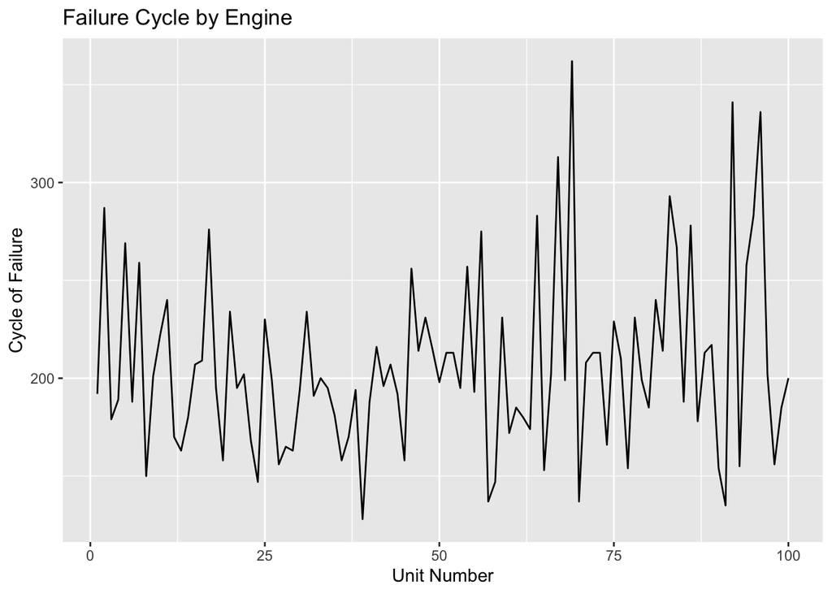

```r
# Find the last Cycle number for each UnitNum (Jet Engine) in the Train set
TrainFailCycle <- as.vector(tapply(train$TimeCycles, train$UnitNum, max))

# Find the last Cycle number for each UnitNum (Jet Engine) in the Test set
TestFailCycle <- as.vector(tapply(test$TimeCycles, test$UnitNum, max))

# Plot Last Cycle per Unit
qplot(y= TrainFailCycle, x=1:length(TrainFailCycle), main = 'Failure Cycle by Engine', ylab = 'Cycle of Failure', xlab = 'Unit Number', geom = "line")
```

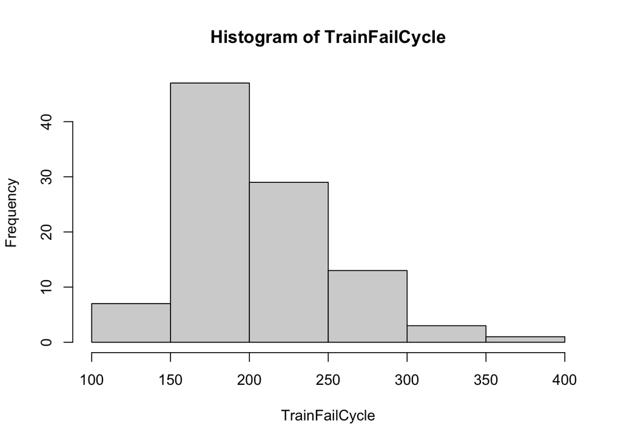

```r
# Show distribution of Failure Cycle in Engines
hist(TrainFailCycle)
```

In the process of preparing the data for the prediction model we need to consider the data provided in the test set. We have noticed that the Test data won’t provide a value specifying the last cycle when the engine failed.

*Why this value is important in the test set?*

Basically, since the prediction model will predict the number of the last cycle before the engine fail we need to have a comparison point between the train set and the test set. Prediction model will generate a Cycles-to-Fail value that needs to be compared to the real value to understand the accuracy and/of efficiency of the model and provide a base to calculate residuals.

Since this value was not provide we have a way to calculate them both for the Train and Test sets.

For the Train set, is assumed that the last cycle number in the data is the failure cycle hence we apply the max number of cycles by engine backwards so the value of “CyclestoFail” is 0 in the last cycle in the engine data.

For the Test set, we have the real RUL value provided in the RUL_FD001 file. We’ll use this value to perform a calculation that will make that the “CyclestoFail” value on the last reported cycle by engine equals to the RUL value in the RUL file.

Once this process is completed well start evaluating and visualizing the correlation between the preliminary selected variables.

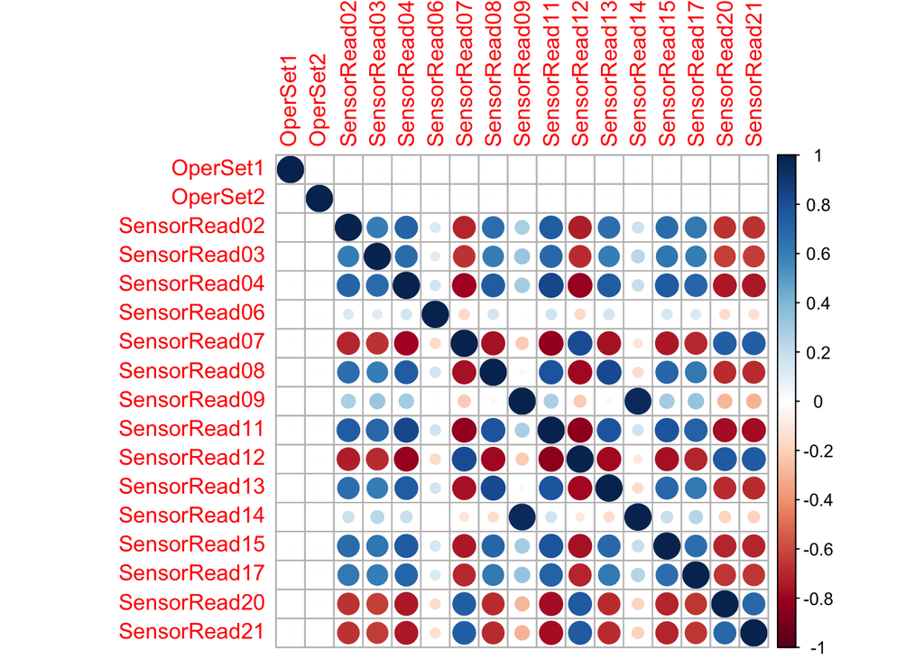

```r
# Get RUL values for file
RealCTF <- unlist(CTF)

# Calculate Cycles to Fails Value for Train Set
train$CyclesToFail <- TrainFailCycle[train$UnitNum] - train$TimeCycles

# Calculate Cycles to Fails Value for Test Set
test$CyclesToFail <-   RealCTF[test$UnitNum] + TestFailCycle[test$UnitNum]
test$CyclesToFail <-  test$CyclesToFail - test$TimeCycles

# Build the preliminary list of variables for the prediction model
num_cols = c('OperSet1','OperSet2','SensorRead02','SensorRead03','SensorRead04','SensorRead06','SensorRead07','SensorRead08','SensorRead09',
             'SensorRead11','SensorRead12','SensorRead13','SensorRead14','SensorRead15','SensorRead17','SensorRead20','SensorRead21')


# Calculate Correlations between variables
correlations <- cor(data.frame(train[,num_cols]))

# Visualize correlations
corrplot(correlations)
```

In a continue effort to provide a better foundation for the creation of the prediction model, let’s review a valiable heatmap and a clusterized version of the correlogram

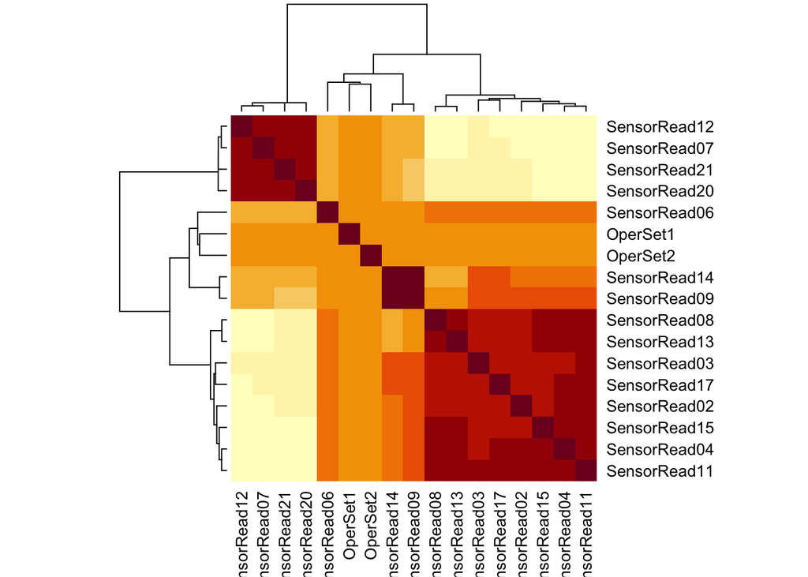

```r
rev_correl <- cor(data.frame(train[,num_cols]))

heatmap(rev_correl, symm = TRUE)
```

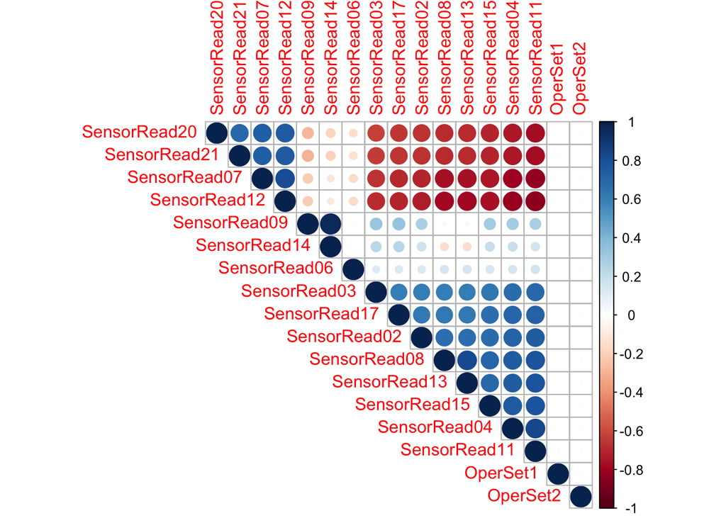

```r
corrplot(rev_correl, type = "upper",  order = 'hclust')
```

In conclusion, by looking at the plots from all Variables and combining with the observation in the Heatmaps and Correlograms this is the final list of Variables to use in the construction of the models:

| Section | Variable |
| --- | --- |
| Sensor Readings | SensorRead02 |
| Sensor Readings | SensorRead03 |
| Sensor Readings | SensorRead04 |
| Sensor Readings | SensorRead07 |
| Sensor Readings | SensorRead08 |
| Sensor Readings | SensorRead09 |
| Sensor Readings | SensorRead11 |
| Sensor Readings | SensorRead12 |
| Sensor Readings | SensorRead13 |
| Sensor Readings | SensorRead14 |
| Sensor Readings | SensorRead15 |
| Sensor Readings | SensorRead17 |
| Sensor Readings | SensorRead20 |
| Sensor Readings | SensorRead21 |

## Prediction Model Testing

However the majority of the TimeCyle series the relationship is linear, for that reason the approach on this model selection will be focus in test the linear regression model and the polynomial regression and evaluate which one performs better.

### Linear Regression model

```r
# Scaling numeric Values
preProcValues <- preProcess(train[,rev_cols], method = c("center", "scale"))
train[,rev_cols] = predict(preProcValues, train[,rev_cols])
test[,rev_cols] = predict(preProcValues, test[,rev_cols])

# Set variables for the Train model
TrainFormula <- CyclesToFail ~ SensorRead02 + SensorRead03 + SensorRead04 + SensorRead07 + SensorRead08 + SensorRead09 +
  SensorRead11 + SensorRead12 + SensorRead13 + SensorRead14 + SensorRead15 + SensorRead17 + SensorRead20 + SensorRead21
```

Once we have scaled all Numerical values we proceed to create and test the Linear regression Model

```r
# Create Linear Regression Model
lin_mod = lm(TrainFormula, data = train)
test$LR_score <- predict(lin_mod, newdata = test)


# Model performance
print_metrics(lin_mod, test, 'LR_score', 'CyclesToFail')
```

```
## Mean Square Error      =  30640291.1992
## Root Mean Square Error =  5535.3673
## Mean Absolute Error    =  486550.5706
## Median Absolute Error  =  30.1672
## R^2                    =  0.5794
## Adjusted R^2           =  0.5792
```

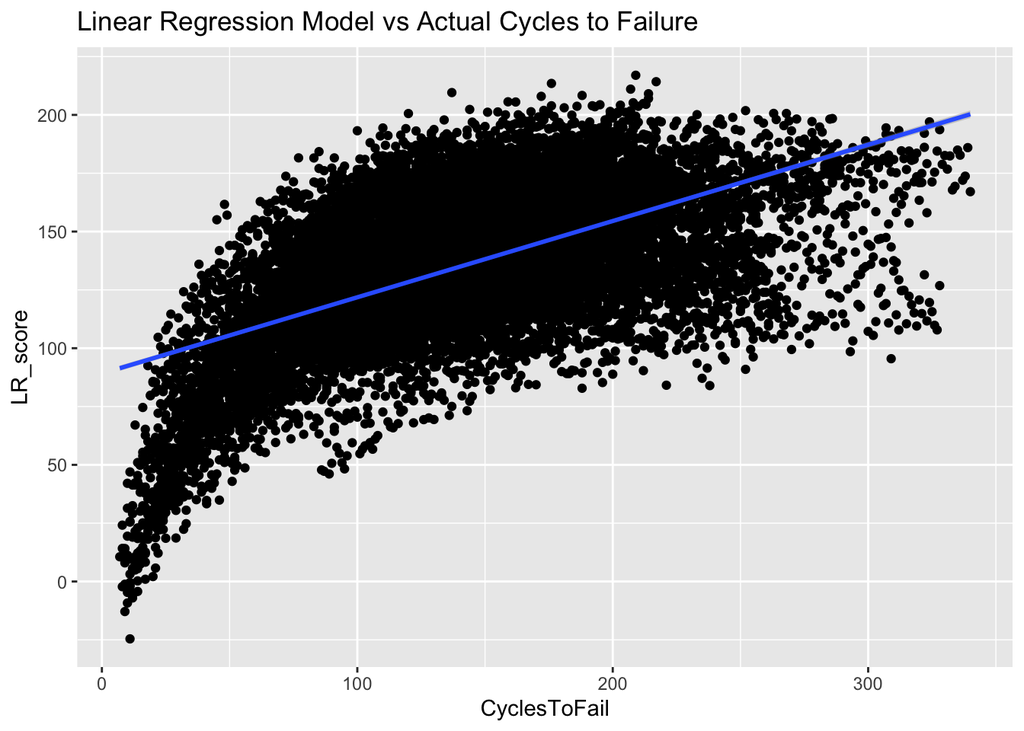

```r
# Visualize Linear Regression Model

ggplot(test, aes(CyclesToFail, LR_score) ) +
  geom_point() +
  stat_smooth(method = lm, formula = y ~ x) +
  ggtitle('Linear Regression Model vs Actual Cycles to Failure')
```

Given the R-Squared value of 0.58 we can conclude that this model basically is not fitted for the purpose. Additionaly as depicted in the plot above the Linear Model does not fit properly th obseved distribution of values.

### Polynomial Regression model [^3]

Let’s now explore the polynomial Regression model as it offers a better performance is cases where a non-linear behavior is observed.

```r
# Build the model
poly_model <- lm(CyclesToFail ~ polym(SensorRead02, SensorRead03, SensorRead04, SensorRead07, SensorRead08, SensorRead09,
                                      SensorRead11, SensorRead12, SensorRead13, SensorRead14,
                                      SensorRead15, SensorRead17, SensorRead20, SensorRead21,
                                      degree = 2, raw = TRUE), data = train)


# Make predictions
test$poly_score <- predict(poly_model, newdata = test)
predictions <- poly_model %>% predict(test)
# Model performance
print_metrics(poly_model, test, 'poly_score', 'CyclesToFail')
```

```
## Mean Square Error      =  28472515.8379
## Root Mean Square Error =  5335.9644
## Mean Absolute Error    =  462004.3866
## Median Absolute Error  =  27.5321
## R^2                    =  0.6265
## Adjusted R^2           =  0.6244
```

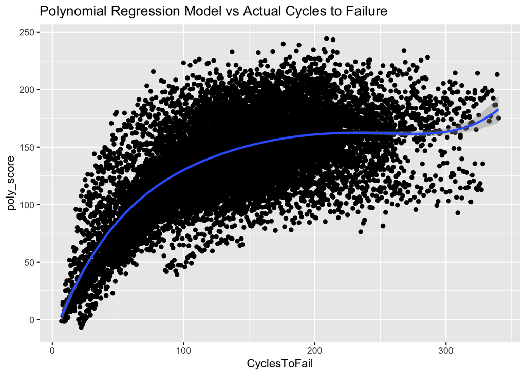

```r
# Plot Model Accuracy
ggplot(test, aes(CyclesToFail, poly_score) ) +
  geom_point() +
  stat_smooth(method = lm, formula = y ~ poly(x, 5, raw = TRUE)) +
  ggtitle('Polynomial Regression Model vs Actual Cycles to Failure')
```

The last plotted chart shows a better fitted model to the observed values and exhibiting a better R-squared value 0.63

### Findings

- Data preparation and variable enhancements is key in the process of data analysis. In this case we have a very clean dataset obtained from a accredited and recognized entity such NASA, however the data was not provided in a way that facilitates the process of results validation on the applied models
- A polynomial regression model resulted in a better fit for the problem presented.
- Variable selection for model training can be supplemented by an initial revision on supporting tools and methods such correlograms, heatmaps and variable plots charts
[^1]: A. Saxena and K. Goebel (2008). “Turbofan Engine Degradation Simulation Data Set”, NASA Ames Prognostics Data Repository (http://ti.arc.nasa.gov/project/prognostic-data-repository), NASA Ames Research Center, Moffett Field, CA
[^2]: What are Predictive Analytics and how important are they to effective Asset Management? (https://www.processindustryforum.com/article/predictive-analytics-important-effective-asset-management)
[^3]: Nonlinear Regression Essentials in R: Polynomial and Spline Regression Models (http://www.sthda.com/english/articles/40-regression-analysis/162-nonlinear-regression-essentials-in-r-polynomial-and-spline-regression-models/)